# Risk Factor Analysis

## Outcome Variable

**Outcome Variable:** wasted

## Predictor Variables

**Intervention Variable:** mhtcm

**Adjustment Set:**

- arm
- W_mage
- meducyrs
- feducyrs
- single
- delta_W_mage
- delta_meducyrs
- delta_feducyrs
- delta_single

## Stratifying Variables

The analysis was stratified on these variable(s):

- agecat
- studyid
- country

## Data Summary

| agecat | studyid | country | mhtcm | wasted | n_cell | n |
| --- | --- | --- | --- | --- | --- | --- |
| Birth | COHORTS | GUATEMALA | >=155 cm | 0 | 72 | 748 |
| Birth | COHORTS | GUATEMALA | >=155 cm | 1 | 31 | 748 |
| Birth | COHORTS | GUATEMALA | <151 cm | 0 | 360 | 748 |
| Birth | COHORTS | GUATEMALA | <151 cm | 1 | 124 | 748 |
| Birth | COHORTS | GUATEMALA | [151-155) cm | 0 | 127 | 748 |
| Birth | COHORTS | GUATEMALA | [151-155) cm | 1 | 34 | 748 |
| Birth | COHORTS | INDIA | >=155 cm | 0 | 406 | 1676 |
| Birth | COHORTS | INDIA | >=155 cm | 1 | 102 | 1676 |
| Birth | COHORTS | INDIA | <151 cm | 0 | 597 | 1676 |
| Birth | COHORTS | INDIA | <151 cm | 1 | 115 | 1676 |
| Birth | COHORTS | INDIA | [151-155) cm | 0 | 382 | 1676 |
| Birth | COHORTS | INDIA | [151-155) cm | 1 | 74 | 1676 |
| Birth | COHORTS | PHILIPPINES | >=155 cm | 0 | 520 | 2899 |
| Birth | COHORTS | PHILIPPINES | >=155 cm | 1 | 96 | 2899 |
| Birth | COHORTS | PHILIPPINES | <151 cm | 0 | 1216 | 2899 |
| Birth | COHORTS | PHILIPPINES | <151 cm | 1 | 229 | 2899 |
| Birth | COHORTS | PHILIPPINES | [151-155) cm | 0 | 712 | 2899 |
| Birth | COHORTS | PHILIPPINES | [151-155) cm | 1 | 126 | 2899 |
| Birth | JiVitA-3 | BANGLADESH | >=155 cm | 0 | 2656 | 17936 |
| Birth | JiVitA-3 | BANGLADESH | >=155 cm | 1 | 310 | 17936 |
| Birth | JiVitA-3 | BANGLADESH | <151 cm | 0 | 9086 | 17936 |
| Birth | JiVitA-3 | BANGLADESH | <151 cm | 1 | 1173 | 17936 |
| Birth | JiVitA-3 | BANGLADESH | [151-155) cm | 0 | 4226 | 17936 |
| Birth | JiVitA-3 | BANGLADESH | [151-155) cm | 1 | 485 | 17936 |
| Birth | Keneba | GAMBIA | >=155 cm | 0 | 855 | 1362 |
| Birth | Keneba | GAMBIA | >=155 cm | 1 | 280 | 1362 |
| Birth | Keneba | GAMBIA | <151 cm | 0 | 32 | 1362 |
| Birth | Keneba | GAMBIA | <151 cm | 1 | 14 | 1362 |
| Birth | Keneba | GAMBIA | [151-155) cm | 0 | 135 | 1362 |
| Birth | Keneba | GAMBIA | [151-155) cm | 1 | 46 | 1362 |

[output cut: 324 more lines]

The following strata were considered:

- agecat: 24 months, studyid: COHORTS, country: GUATEMALA
- agecat: 24 months, studyid: COHORTS, country: INDIA
- agecat: 24 months, studyid: COHORTS, country: PHILIPPINES
- agecat: 24 months, studyid: JiVitA-3, country: BANGLADESH
- agecat: 24 months, studyid: Keneba, country: GAMBIA
- agecat: 24 months, studyid: LCNI-5, country: MALAWI
- agecat: 24 months, studyid: MAL-ED, country: BANGLADESH
- agecat: 24 months, studyid: MAL-ED, country: BRAZIL
- agecat: 24 months, studyid: MAL-ED, country: INDIA
- agecat: 24 months, studyid: MAL-ED, country: NEPAL
- agecat: 24 months, studyid: MAL-ED, country: PERU
- agecat: 24 months, studyid: MAL-ED, country: SOUTH AFRICA
- agecat: 24 months, studyid: MAL-ED, country: TANZANIA, UNITED REPUBLIC OF
- agecat: 24 months, studyid: NIH-Birth, country: BANGLADESH
- agecat: 24 months, studyid: NIH-Crypto, country: BANGLADESH
- agecat: 24 months, studyid: PROBIT, country: BELARUS
- agecat: 24 months, studyid: PROVIDE, country: BANGLADESH
- agecat: 24 months, studyid: TanzaniaChild2, country: TANZANIA, UNITED REPUBLIC OF
- agecat: 24 months, studyid: ZVITAMBO, country: ZIMBABWE
- agecat: 6 months, studyid: COHORTS, country: GUATEMALA
- agecat: 6 months, studyid: COHORTS, country: INDIA
- agecat: 6 months, studyid: COHORTS, country: PHILIPPINES
- agecat: 6 months, studyid: Guatemala BSC, country: GUATEMALA
- agecat: 6 months, studyid: JiVitA-3, country: BANGLADESH
- agecat: 6 months, studyid: Keneba, country: GAMBIA
- agecat: 6 months, studyid: LCNI-5, country: MALAWI
- agecat: 6 months, studyid: MAL-ED, country: BANGLADESH
- agecat: 6 months, studyid: MAL-ED, country: BRAZIL
- agecat: 6 months, studyid: MAL-ED, country: INDIA
- agecat: 6 months, studyid: MAL-ED, country: NEPAL
- agecat: 6 months, studyid: MAL-ED, country: PERU
- agecat: 6 months, studyid: MAL-ED, country: SOUTH AFRICA
- agecat: 6 months, studyid: MAL-ED, country: TANZANIA, UNITED REPUBLIC OF
- agecat: 6 months, studyid: NIH-Birth, country: BANGLADESH
- agecat: 6 months, studyid: NIH-Crypto, country: BANGLADESH
- agecat: 6 months, studyid: PROBIT, country: BELARUS
- agecat: 6 months, studyid: PROVIDE, country: BANGLADESH
- agecat: 6 months, studyid: SAS-CompFeed, country: INDIA
- agecat: 6 months, studyid: SAS-FoodSuppl, country: INDIA
- agecat: 6 months, studyid: TanzaniaChild2, country: TANZANIA, UNITED REPUBLIC OF
- agecat: 6 months, studyid: ZVITAMBO, country: ZIMBABWE
- agecat: Birth, studyid: COHORTS, country: GUATEMALA
- agecat: Birth, studyid: COHORTS, country: INDIA
- agecat: Birth, studyid: COHORTS, country: PHILIPPINES
- agecat: Birth, studyid: JiVitA-3, country: BANGLADESH
- agecat: Birth, studyid: Keneba, country: GAMBIA
- agecat: Birth, studyid: MAL-ED, country: BANGLADESH
- agecat: Birth, studyid: MAL-ED, country: BRAZIL
- agecat: Birth, studyid: MAL-ED, country: INDIA
- agecat: Birth, studyid: MAL-ED, country: NEPAL
- agecat: Birth, studyid: MAL-ED, country: PERU
- agecat: Birth, studyid: MAL-ED, country: SOUTH AFRICA
- agecat: Birth, studyid: MAL-ED, country: TANZANIA, UNITED REPUBLIC OF
- agecat: Birth, studyid: NIH-Birth, country: BANGLADESH
- agecat: Birth, studyid: NIH-Crypto, country: BANGLADESH
- agecat: Birth, studyid: PROBIT, country: BELARUS
- agecat: Birth, studyid: PROVIDE, country: BANGLADESH
- agecat: Birth, studyid: SAS-CompFeed, country: INDIA
- agecat: Birth, studyid: ZVITAMBO, country: ZIMBABWE

### Dropped Strata

Some strata were dropped due to rare outcomes:

- agecat: Birth, studyid: MAL-ED, country: BANGLADESH
- agecat: Birth, studyid: MAL-ED, country: BRAZIL
- agecat: Birth, studyid: MAL-ED, country: INDIA
- agecat: Birth, studyid: MAL-ED, country: NEPAL
- agecat: Birth, studyid: MAL-ED, country: PERU
- agecat: Birth, studyid: MAL-ED, country: SOUTH AFRICA
- agecat: Birth, studyid: MAL-ED, country: TANZANIA, UNITED REPUBLIC OF
- agecat: 6 months, studyid: COHORTS, country: GUATEMALA
- agecat: 6 months, studyid: Guatemala BSC, country: GUATEMALA
- agecat: 6 months, studyid: LCNI-5, country: MALAWI
- agecat: 6 months, studyid: MAL-ED, country: BANGLADESH
- agecat: 6 months, studyid: MAL-ED, country: BRAZIL
- agecat: 6 months, studyid: MAL-ED, country: NEPAL
- agecat: 6 months, studyid: MAL-ED, country: PERU
- agecat: 6 months, studyid: MAL-ED, country: SOUTH AFRICA
- agecat: 6 months, studyid: MAL-ED, country: TANZANIA, UNITED REPUBLIC OF
- agecat: 6 months, studyid: NIH-Crypto, country: BANGLADESH
- agecat: 6 months, studyid: PROBIT, country: BELARUS
- agecat: 24 months, studyid: LCNI-5, country: MALAWI
- agecat: 24 months, studyid: MAL-ED, country: BANGLADESH
- agecat: 24 months, studyid: MAL-ED, country: BRAZIL
- agecat: 24 months, studyid: MAL-ED, country: INDIA
- agecat: 24 months, studyid: MAL-ED, country: NEPAL
- agecat: 24 months, studyid: MAL-ED, country: PERU
- agecat: 24 months, studyid: MAL-ED, country: SOUTH AFRICA
- agecat: 24 months, studyid: MAL-ED, country: TANZANIA, UNITED REPUBLIC OF
- agecat: 24 months, studyid: PROBIT, country: BELARUS
- agecat: 24 months, studyid: TanzaniaChild2, country: TANZANIA, UNITED REPUBLIC OF

## Methods Detail

We’re interested in the causal parameters $E[Y_a]$ for all values of $a \in \mathcal{A}$. These parameters represent the mean outcome if, possibly contrary to fact, we intervened to set all units to have $A=a$. Under the randomization and positivity assumptions, these are identified by the statistical parameters $\psi_a=E_W[E_{Y|A,W}(Y|A=a,W)]$. In addition, we’re interested in the mean of $Y$, $E[Y]$ under no intervention (the observed mean). We will estimate these parameters by using SuperLearner to fit the relevant likelihood factors – $E_{Y|A,W}(Y|A=a,W)$ and $p(A=a|W)$, and then updating our likelihood fit using a joint TMLE.

For unadjusted analyses ($W=\{\}$), initial likelihoods were estimated using Lrnr_glm to estimate the simple $E(Y|A)$ and Lrnr_mean to estimate $p(A)$. For adjusted analyses, a small library containing Lrnr_glmnet, Lrnr_xgboost, and Lrnr_mean was used.

Having estimated these parameters, we will then use the delta method to estimate relative risks and attributable risks relative to a prespecified baseline level of $A$.

# Results Detail

## Results Plots

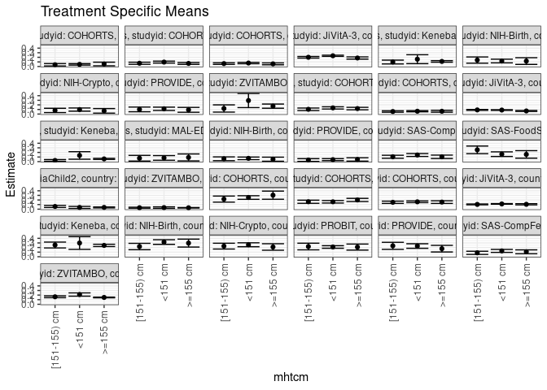

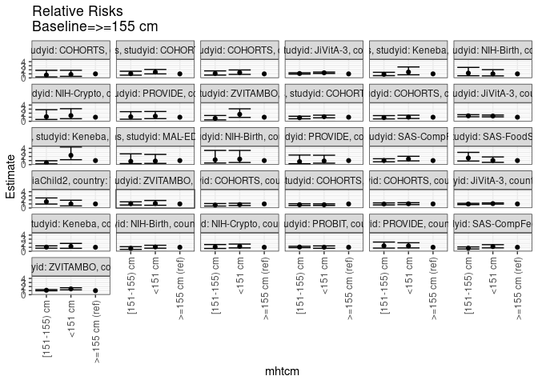

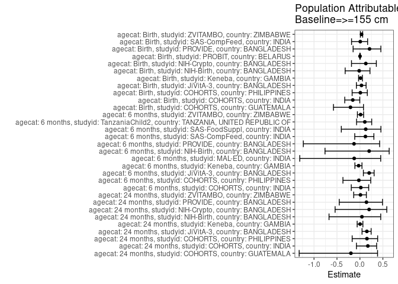

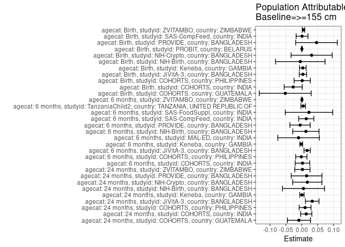

## Results Table

### Parameter: TSM

| agecat | studyid | country | intervention_level | baseline_level | estimate | ci_lower | ci_upper |
| --- | --- | --- | --- | --- | --- | --- | --- |
| Birth | COHORTS | GUATEMALA | >=155 cm | NA | 0.3046950 | 0.2161615 | 0.3932286 |
| Birth | COHORTS | GUATEMALA | <151 cm | NA | 0.2534626 | 0.2145324 | 0.2923927 |
| Birth | COHORTS | GUATEMALA | [151-155) cm | NA | 0.2191410 | 0.1533437 | 0.2849382 |
| Birth | COHORTS | INDIA | >=155 cm | NA | 0.2006075 | 0.1658805 | 0.2353346 |
| Birth | COHORTS | INDIA | <151 cm | NA | 0.1604638 | 0.1334158 | 0.1875118 |
| Birth | COHORTS | INDIA | [151-155) cm | NA | 0.1612915 | 0.1273035 | 0.1952794 |
| Birth | COHORTS | PHILIPPINES | >=155 cm | NA | 0.1541105 | 0.1253018 | 0.1829193 |
| Birth | COHORTS | PHILIPPINES | <151 cm | NA | 0.1599927 | 0.1410964 | 0.1788889 |
| Birth | COHORTS | PHILIPPINES | [151-155) cm | NA | 0.1496983 | 0.1251512 | 0.1742453 |
| Birth | JiVitA-3 | BANGLADESH | >=155 cm | NA | 0.1059383 | 0.0930348 | 0.1188417 |
| Birth | JiVitA-3 | BANGLADESH | <151 cm | NA | 0.1142698 | 0.1077528 | 0.1207868 |
| Birth | JiVitA-3 | BANGLADESH | [151-155) cm | NA | 0.1035386 | 0.0940058 | 0.1130713 |
| Birth | Keneba | GAMBIA | >=155 cm | NA | 0.2462676 | 0.2211729 | 0.2713623 |
| Birth | Keneba | GAMBIA | <151 cm | NA | 0.2982296 | 0.1598053 | 0.4366539 |
| Birth | Keneba | GAMBIA | [151-155) cm | NA | 0.2546283 | 0.1908735 | 0.3183831 |
| Birth | NIH-Birth | BANGLADESH | >=155 cm | NA | 0.2969005 | 0.2104082 | 0.3833928 |
| Birth | NIH-Birth | BANGLADESH | <151 cm | NA | 0.3197919 | 0.2694178 | 0.3701661 |
| Birth | NIH-Birth | BANGLADESH | [151-155) cm | NA | 0.2219016 | 0.1524328 | 0.2913704 |
| Birth | NIH-Crypto | BANGLADESH | >=155 cm | NA | 0.2117597 | 0.1409585 | 0.2825609 |
| Birth | NIH-Crypto | BANGLADESH | <151 cm | NA | 0.2600953 | 0.2172476 | 0.3029430 |
| Birth | NIH-Crypto | BANGLADESH | [151-155) cm | NA | 0.2302991 | 0.1670327 | 0.2935655 |
| Birth | PROBIT | BELARUS | >=155 cm | NA | 0.2098084 | 0.1441063 | 0.2755105 |
| Birth | PROBIT | BELARUS | <151 cm | NA | 0.2122528 | 0.1845712 | 0.2399343 |
| Birth | PROBIT | BELARUS | [151-155) cm | NA | 0.2217523 | 0.1493625 | 0.2941422 |
| Birth | PROVIDE | BANGLADESH | >=155 cm | NA | 0.1750931 | 0.1030157 | 0.2471706 |
| Birth | PROVIDE | BANGLADESH | <151 cm | NA | 0.2328426 | 0.1833942 | 0.2822911 |
| Birth | PROVIDE | BANGLADESH | [151-155) cm | NA | 0.2369611 | 0.1602179 | 0.3137043 |
| Birth | SAS-CompFeed | INDIA | >=155 cm | NA | 0.1070039 | 0.0648961 | 0.1491116 |
| Birth | SAS-CompFeed | INDIA | <151 cm | NA | 0.1265614 | 0.0941088 | 0.1590140 |
| Birth | SAS-CompFeed | INDIA | [151-155) cm | NA | 0.0847809 | 0.0507819 | 0.1187798 |

[output cut: 63 more lines]

### Parameter: E(Y)

| agecat | studyid | country | intervention_level | baseline_level | estimate | ci_lower | ci_upper |
| --- | --- | --- | --- | --- | --- | --- | --- |
| Birth | COHORTS | GUATEMALA | NA | NA | 0.2526738 | 0.2215120 | 0.2838356 |
| Birth | COHORTS | INDIA | NA | NA | 0.1736277 | 0.1554877 | 0.1917677 |
| Birth | COHORTS | PHILIPPINES | NA | NA | 0.1555709 | 0.1423748 | 0.1687670 |
| Birth | JiVitA-3 | BANGLADESH | NA | NA | 0.1097235 | 0.1045842 | 0.1148627 |
| Birth | Keneba | GAMBIA | NA | NA | 0.2496329 | 0.2266393 | 0.2726265 |
| Birth | NIH-Birth | BANGLADESH | NA | NA | 0.2921739 | 0.2549711 | 0.3293768 |
| Birth | NIH-Crypto | BANGLADESH | NA | NA | 0.2428977 | 0.2111977 | 0.2745977 |
| Birth | PROBIT | BELARUS | NA | NA | 0.2102219 | 0.1448555 | 0.2755882 |
| Birth | PROVIDE | BANGLADESH | NA | NA | 0.2215686 | 0.1854897 | 0.2576475 |
| Birth | SAS-CompFeed | INDIA | NA | NA | 0.1078629 | 0.0749278 | 0.1407980 |
| Birth | ZVITAMBO | ZIMBABWE | NA | NA | 0.1541943 | 0.1467576 | 0.1616309 |
| 6 months | COHORTS | INDIA | NA | NA | 0.1214953 | 0.1064776 | 0.1365130 |
| 6 months | COHORTS | PHILIPPINES | NA | NA | 0.0594974 | 0.0505830 | 0.0684118 |
| 6 months | JiVitA-3 | BANGLADESH | NA | NA | 0.0845584 | 0.0797428 | 0.0893740 |
| 6 months | Keneba | GAMBIA | NA | NA | 0.0570059 | 0.0465142 | 0.0674976 |
| 6 months | MAL-ED | INDIA | NA | NA | 0.0808511 | 0.0459229 | 0.1157792 |
| 6 months | NIH-Birth | BANGLADESH | NA | NA | 0.0651769 | 0.0442802 | 0.0860736 |
| 6 months | PROVIDE | BANGLADESH | NA | NA | 0.0415282 | 0.0255778 | 0.0574787 |
| 6 months | SAS-CompFeed | INDIA | NA | NA | 0.1190865 | 0.0945854 | 0.1435876 |
| 6 months | SAS-FoodSuppl | INDIA | NA | NA | 0.1794195 | 0.1407385 | 0.2181005 |
| 6 months | TanzaniaChild2 | TANZANIA, UNITED REPUBLIC OF | NA | NA | 0.0426065 | 0.0337417 | 0.0514713 |
| 6 months | ZVITAMBO | ZIMBABWE | NA | NA | 0.0306740 | 0.0267100 | 0.0346380 |
| 24 months | COHORTS | GUATEMALA | NA | NA | 0.0457256 | 0.0328110 | 0.0586403 |
| 24 months | COHORTS | INDIA | NA | NA | 0.0809762 | 0.0683807 | 0.0935716 |
| 24 months | COHORTS | PHILIPPINES | NA | NA | 0.0681911 | 0.0582056 | 0.0781766 |
| 24 months | JiVitA-3 | BANGLADESH | NA | NA | 0.2179697 | 0.2080911 | 0.2278482 |
| 24 months | Keneba | GAMBIA | NA | NA | 0.1110418 | 0.0956567 | 0.1264269 |
| 24 months | NIH-Birth | BANGLADESH | NA | NA | 0.1238318 | 0.0925894 | 0.1550741 |
| 24 months | NIH-Crypto | BANGLADESH | NA | NA | 0.0875486 | 0.0630907 | 0.1120065 |
| 24 months | PROVIDE | BANGLADESH | NA | NA | 0.1072664 | 0.0820169 | 0.1325160 |
| 24 months | ZVITAMBO | ZIMBABWE | NA | NA | 0.1743869 | 0.1355135 | 0.2132603 |

### Parameter: RR

| agecat | studyid | country | intervention_level | baseline_level | estimate | ci_lower | ci_upper |
| --- | --- | --- | --- | --- | --- | --- | --- |
| Birth | COHORTS | GUATEMALA | >=155 cm | >=155 cm | 1.0000000 | 1.0000000 | 1.0000000 |
| Birth | COHORTS | GUATEMALA | <151 cm | >=155 cm | 0.8318566 | 0.5987983 | 1.1556235 |
| Birth | COHORTS | GUATEMALA | [151-155) cm | >=155 cm | 0.7192141 | 0.4736467 | 1.0920988 |
| Birth | COHORTS | INDIA | >=155 cm | >=155 cm | 1.0000000 | 1.0000000 | 1.0000000 |
| Birth | COHORTS | INDIA | <151 cm | >=155 cm | 0.7998892 | 0.6281604 | 1.0185659 |
| Birth | COHORTS | INDIA | [151-155) cm | >=155 cm | 0.8040150 | 0.6120817 | 1.0561337 |
| Birth | COHORTS | PHILIPPINES | >=155 cm | >=155 cm | 1.0000000 | 1.0000000 | 1.0000000 |
| Birth | COHORTS | PHILIPPINES | <151 cm | >=155 cm | 1.0381685 | 0.8323234 | 1.2949220 |
| Birth | COHORTS | PHILIPPINES | [151-155) cm | >=155 cm | 0.9713696 | 0.7576458 | 1.2453826 |
| Birth | JiVitA-3 | BANGLADESH | >=155 cm | >=155 cm | 1.0000000 | 1.0000000 | 1.0000000 |
| Birth | JiVitA-3 | BANGLADESH | <151 cm | >=155 cm | 1.0786451 | 0.9465015 | 1.2292376 |
| Birth | JiVitA-3 | BANGLADESH | [151-155) cm | >=155 cm | 0.9773482 | 0.8376936 | 1.1402852 |
| Birth | Keneba | GAMBIA | >=155 cm | >=155 cm | 1.0000000 | 1.0000000 | 1.0000000 |
| Birth | Keneba | GAMBIA | <151 cm | >=155 cm | 1.2109984 | 0.7529542 | 1.9476843 |
| Birth | Keneba | GAMBIA | [151-155) cm | >=155 cm | 1.0339499 | 0.7891594 | 1.3546724 |
| Birth | NIH-Birth | BANGLADESH | >=155 cm | >=155 cm | 1.0000000 | 1.0000000 | 1.0000000 |
| Birth | NIH-Birth | BANGLADESH | <151 cm | >=155 cm | 1.0771013 | 0.7736927 | 1.4994934 |
| Birth | NIH-Birth | BANGLADESH | [151-155) cm | >=155 cm | 0.7473938 | 0.4879764 | 1.1447224 |
| Birth | NIH-Crypto | BANGLADESH | >=155 cm | >=155 cm | 1.0000000 | 1.0000000 | 1.0000000 |
| Birth | NIH-Crypto | BANGLADESH | <151 cm | >=155 cm | 1.2282567 | 0.8460115 | 1.7832082 |
| Birth | NIH-Crypto | BANGLADESH | [151-155) cm | >=155 cm | 1.0875491 | 0.7053891 | 1.6767525 |
| Birth | PROBIT | BELARUS | >=155 cm | >=155 cm | 1.0000000 | 1.0000000 | 1.0000000 |
| Birth | PROBIT | BELARUS | <151 cm | >=155 cm | 1.0116504 | 0.7618066 | 1.3434335 |
| Birth | PROBIT | BELARUS | [151-155) cm | >=155 cm | 1.0569277 | 0.9050885 | 1.2342398 |
| Birth | PROVIDE | BANGLADESH | >=155 cm | >=155 cm | 1.0000000 | 1.0000000 | 1.0000000 |
| Birth | PROVIDE | BANGLADESH | <151 cm | >=155 cm | 1.3298215 | 0.8367466 | 2.1134539 |
| Birth | PROVIDE | BANGLADESH | [151-155) cm | >=155 cm | 1.3533432 | 0.8012440 | 2.2858677 |
| Birth | SAS-CompFeed | INDIA | >=155 cm | >=155 cm | 1.0000000 | 1.0000000 | 1.0000000 |
| Birth | SAS-CompFeed | INDIA | <151 cm | >=155 cm | 1.1827742 | 0.8525998 | 1.6408105 |
| Birth | SAS-CompFeed | INDIA | [151-155) cm | >=155 cm | 0.7923158 | 0.5776713 | 1.0867156 |

[output cut: 63 more lines]

### Parameter: PAR

| agecat | studyid | country | intervention_level | baseline_level | estimate | ci_lower | ci_upper |
| --- | --- | --- | --- | --- | --- | --- | --- |
| Birth | COHORTS | GUATEMALA | >=155 cm | NA | -0.0520213 | -0.1336919 | 0.0296494 |
| Birth | COHORTS | INDIA | >=155 cm | NA | -0.0269799 | -0.0553802 | 0.0014205 |
| Birth | COHORTS | PHILIPPINES | >=155 cm | NA | 0.0014604 | -0.0241415 | 0.0270622 |
| Birth | JiVitA-3 | BANGLADESH | >=155 cm | NA | 0.0037852 | -0.0077844 | 0.0153548 |
| Birth | Keneba | GAMBIA | >=155 cm | NA | 0.0033653 | -0.0070501 | 0.0137808 |
| Birth | NIH-Birth | BANGLADESH | >=155 cm | NA | -0.0047266 | -0.0827893 | 0.0733361 |
| Birth | NIH-Crypto | BANGLADESH | >=155 cm | NA | 0.0311380 | -0.0336459 | 0.0959219 |
| Birth | PROBIT | BELARUS | >=155 cm | NA | 0.0004134 | -0.0007504 | 0.0015772 |
| Birth | PROVIDE | BANGLADESH | >=155 cm | NA | 0.0464755 | -0.0191790 | 0.1121300 |
| Birth | SAS-CompFeed | INDIA | >=155 cm | NA | 0.0008590 | -0.0178330 | 0.0195510 |
| Birth | ZVITAMBO | ZIMBABWE | >=155 cm | NA | 0.0055112 | 0.0016495 | 0.0093729 |
| 6 months | COHORTS | INDIA | >=155 cm | NA | 0.0023967 | -0.0205155 | 0.0253089 |
| 6 months | COHORTS | PHILIPPINES | >=155 cm | NA | -0.0013851 | -0.0191542 | 0.0163840 |
| 6 months | JiVitA-3 | BANGLADESH | >=155 cm | NA | 0.0169756 | 0.0070559 | 0.0268952 |
| 6 months | Keneba | GAMBIA | >=155 cm | NA | -0.0016676 | -0.0060571 | 0.0027219 |
| 6 months | MAL-ED | INDIA | >=155 cm | NA | -0.0100580 | -0.0756588 | 0.0555428 |
| 6 months | NIH-Birth | BANGLADESH | >=155 cm | NA | 0.0130936 | -0.0282376 | 0.0544247 |
| 6 months | PROVIDE | BANGLADESH | >=155 cm | NA | -0.0053468 | -0.0373834 | 0.0266899 |
| 6 months | SAS-CompFeed | INDIA | >=155 cm | NA | 0.0143026 | -0.0096445 | 0.0382496 |
| 6 months | SAS-FoodSuppl | INDIA | >=155 cm | NA | 0.0227099 | -0.0519897 | 0.0974095 |
| 6 months | TanzaniaChild2 | TANZANIA, UNITED REPUBLIC OF | >=155 cm | NA | 0.0045520 | -0.0024942 | 0.0115982 |
| 6 months | ZVITAMBO | ZIMBABWE | >=155 cm | NA | 0.0004580 | -0.0016124 | 0.0025283 |
| 24 months | COHORTS | GUATEMALA | >=155 cm | NA | -0.0089619 | -0.0453572 | 0.0274334 |
| 24 months | COHORTS | INDIA | >=155 cm | NA | 0.0139951 | -0.0038052 | 0.0317954 |
| 24 months | COHORTS | PHILIPPINES | >=155 cm | NA | 0.0104346 | -0.0082356 | 0.0291049 |
| 24 months | JiVitA-3 | BANGLADESH | >=155 cm | NA | 0.0329417 | 0.0114856 | 0.0543978 |
| 24 months | Keneba | GAMBIA | >=155 cm | NA | 0.0004715 | -0.0064238 | 0.0073667 |
| 24 months | NIH-Birth | BANGLADESH | >=155 cm | NA | 0.0054107 | -0.0608227 | 0.0716442 |
| 24 months | NIH-Crypto | BANGLADESH | >=155 cm | NA | 0.0175486 | -0.0285912 | 0.0636885 |
| 24 months | PROVIDE | BANGLADESH | >=155 cm | NA | 0.0152557 | -0.0331177 | 0.0636292 |
| 24 months | ZVITAMBO | ZIMBABWE | >=155 cm | NA | 0.0021023 | -0.0218766 | 0.0260812 |

### Parameter: PAF

| agecat | studyid | country | intervention_level | baseline_level | estimate | ci_lower | ci_upper |
| --- | --- | --- | --- | --- | --- | --- | --- |
| Birth | COHORTS | GUATEMALA | >=155 cm | NA | -0.2058830 | -0.5765907 | 0.0776592 |
| Birth | COHORTS | INDIA | >=155 cm | NA | -0.1553891 | -0.3307553 | -0.0031326 |
| Birth | COHORTS | PHILIPPINES | >=155 cm | NA | 0.0093872 | -0.1696415 | 0.1610133 |
| Birth | JiVitA-3 | BANGLADESH | >=155 cm | NA | 0.0344977 | -0.0770267 | 0.1344739 |
| Birth | Keneba | GAMBIA | >=155 cm | NA | 0.0134811 | -0.0291361 | 0.0543334 |
| Birth | NIH-Birth | BANGLADESH | >=155 cm | NA | -0.0161774 | -0.3217810 | 0.2187689 |
| Birth | NIH-Crypto | BANGLADESH | >=155 cm | NA | 0.1281938 | -0.1834827 | 0.3577887 |
| Birth | PROBIT | BELARUS | >=155 cm | NA | 0.0019667 | -0.0037874 | 0.0076878 |
| Birth | PROVIDE | BANGLADESH | >=155 cm | NA | 0.2097566 | -0.1482495 | 0.4561421 |
| Birth | SAS-CompFeed | INDIA | >=155 cm | NA | 0.0079639 | -0.1822033 | 0.1675411 |
| Birth | ZVITAMBO | ZIMBABWE | >=155 cm | NA | 0.0357417 | 0.0104054 | 0.0604293 |
| 6 months | COHORTS | INDIA | >=155 cm | NA | 0.0197266 | -0.1881862 | 0.1912581 |
| 6 months | COHORTS | PHILIPPINES | >=155 cm | NA | -0.0232802 | -0.3700501 | 0.2357197 |
| 6 months | JiVitA-3 | BANGLADESH | >=155 cm | NA | 0.2007556 | 0.0753337 | 0.3091653 |
| 6 months | Keneba | GAMBIA | >=155 cm | NA | -0.0292533 | -0.1090296 | 0.0447844 |
| 6 months | MAL-ED | INDIA | >=155 cm | NA | -0.1244019 | -1.3107895 | 0.4528798 |
| 6 months | NIH-Birth | BANGLADESH | >=155 cm | NA | 0.2008929 | -0.7605959 | 0.6372977 |
| 6 months | PROVIDE | BANGLADESH | >=155 cm | NA | -0.1287500 | -1.2328788 | 0.4294018 |
| 6 months | SAS-CompFeed | INDIA | >=155 cm | NA | 0.1201023 | -0.1128561 | 0.3042946 |
| 6 months | SAS-FoodSuppl | INDIA | >=155 cm | NA | 0.1265744 | -0.4053472 | 0.4571646 |
| 6 months | TanzaniaChild2 | TANZANIA, UNITED REPUBLIC OF | >=155 cm | NA | 0.1068375 | -0.0732682 | 0.2567195 |
| 6 months | ZVITAMBO | ZIMBABWE | >=155 cm | NA | 0.0149296 | -0.0549006 | 0.0801374 |
| 24 months | COHORTS | GUATEMALA | >=155 cm | NA | -0.1959918 | -1.3234737 | 0.3843715 |
| 24 months | COHORTS | INDIA | >=155 cm | NA | 0.1728302 | -0.0758167 | 0.3640089 |
| 24 months | COHORTS | PHILIPPINES | >=155 cm | NA | 0.1530206 | -0.1688778 | 0.3862710 |
| 24 months | JiVitA-3 | BANGLADESH | >=155 cm | NA | 0.1511298 | 0.0464780 | 0.2442957 |
| 24 months | Keneba | GAMBIA | >=155 cm | NA | 0.0042458 | -0.0598249 | 0.0644433 |
| 24 months | NIH-Birth | BANGLADESH | >=155 cm | NA | 0.0436941 | -0.6728694 | 0.4533220 |
| 24 months | NIH-Crypto | BANGLADESH | >=155 cm | NA | 0.2004444 | -0.5407729 | 0.5850854 |
| 24 months | PROVIDE | BANGLADESH | >=155 cm | NA | 0.1422229 | -0.4500818 | 0.4925931 |
| 24 months | ZVITAMBO | ZIMBABWE | >=155 cm | NA | 0.0120552 | -0.1354601 | 0.1404058 |